# Classifying objects in Earth orbit with a neural network

**Course:** EAI (Deep Learning), Fontys  
**Student:** Josif Mitsanski

## 1. Introduction

Right now there are tens of thousands of man made objects going around the Earth. The US Space Force tracks them and CelesTrak publishes the list for free. Every object in that list has a type:

| Code | Meaning |
| --- | --- |
| **PAY** | Payload. A satellite, working or dead. |
| **R/B** | Rocket body. The empty upper stage of the rocket that brought the satellite up. |
| **DEB** | Debris. Broken pieces, covers, bolts and junk from explosions or collisions. |

**My question:** can a neural network guess the type of an object when it only sees the shape of its orbit and a few facts about the launch?

This matters a bit outside of school too. Space agencies want to know how much junk is up there. When a new object is spotted, somebody has to decide what it is. If orbit numbers alone are enough, that decision could be automated.

### Words I use a lot

I am new to neural networks, so I am writing down what the words mean in my own language. If a word below shows up later in the notebook, this is what I mean by it.

| Word | What it means, simply |
| --- | --- |
| **Feature** | One piece of information I give the model, like the height of the orbit. |
| **Label** or **target** | The answer I want it to predict. Here: is it a satellite, a rocket body or debris. |
| **Training** | Showing the model examples with the answers, so it can adjust itself to get them right. |
| **Epoch** | One full pass through all the training examples. Training takes many epochs. |
| **Weights** | The numbers inside the network that get adjusted during training. This is what the model actually learns. |
| **Loss** | A score for how wrong the model is. Training tries to make it as small as possible. Lower is better. |
| **Overfitting** | The model memorised the training examples instead of learning the general rule. It does great on the data it has seen and badly on new data. |
| **Underfitting** | The opposite. The model is too simple or trained too briefly, so it does badly on everything. |
| **Data leakage** | I accidentally gave the model a column that contains the answer. The score looks amazing and means nothing. |
| **Class imbalance** | Some answers are much more common than others. Here, satellites are 9 times more common than rocket bodies. |

### What I will do

1. Load the CelesTrak catalogue and keep only objects that are still in orbit.
2. Throw away the columns that would give the answer away (this is important, see section 3).
3. Build two simple baselines so I have something to compare against.
4. Build a neural network in Keras.
5. Test different settings for **learning rate** and **network size** and see what happens.
6. Pick the best model and test it once on data it has never seen.

### The short version of the result

On the test set the neural network gets **93.7% accuracy** and a **macro F1 of 0.87**. That beats logistic regression (89.8% and 0.74) and it destroys the lazy answer of always guessing the biggest class (57.6% and 0.24).

Satellites and debris are recognised well. Rocket bodies are the hard class, and the model finds most of them but also cries wolf a lot. Section 7 explains why that is a choice I made and not a bug.

## 2. Dataset

### Where it comes from

| **Name** | CelesTrak Satellite Catalog (SATCAT) |
| --- | --- |
| **Link** | https://celestrak.org/satcat/ |
| **File used** | https://celestrak.org/pub/satcat.csv |
| **Column docs** | https://celestrak.org/satcat/satcat-format.php |
| **Downloaded** | 24 September 2026 |
| **Rows** | 70,793 objects |

I downloaded it with the small script `scripts/download_satcat.py` in this repo. The script puts the date in the filename, because CelesTrak updates the file every day and I want to be able to say exactly which version I used.

First I load the file and look at what is inside.

```python
import os
os.environ['TF_CPP_MIN_LOG_LEVEL'] = '3'   # hide tensorflow startup noise

import numpy as np
import pandas as pd
import matplotlib.pyplot as plt
import seaborn as sns
import tensorflow as tf
from tensorflow import keras

SEED = 42
np.random.seed(SEED)
keras.utils.set_random_seed(SEED)

sns.set_theme(style='whitegrid')
plt.rcParams['figure.dpi'] = 110
pd.set_option('display.width', 120)

print('tensorflow', tf.__version__, '| keras', keras.__version__, '| pandas', pd.__version__)
```

```
tensorflow 2.21.0 | keras 3.15.1 | pandas 3.0.6
```

```python
CSV_PATH = '../data/satcat_2026-09-24.csv'
raw = pd.read_csv(CSV_PATH)

print('rows:', len(raw), ' columns:', raw.shape[1])
raw.head(3)
```

```
rows: 70793  columns: 17
```

|  | OBJECT_NAME | OBJECT_ID | NORAD_CAT_ID | OBJECT_TYPE | OPS_STATUS_CODE | OWNER | LAUNCH_DATE | LAUNCH_SITE | DECAY_DATE | PERIOD | INCLINATION | APOGEE | PERIGEE | RCS | DATA_STATUS_CODE | ORBIT_CENTER | ORBIT_TYPE |
| --- | --- | --- | --- | --- | --- | --- | --- | --- | --- | --- | --- | --- | --- | --- | --- | --- | --- |
| 0 | SL-1 R/B | 1957-001A | 1 | R/B | D | CIS | 1957-10-04 | TYMSC | 1957-12-01 | 96.19 | 65.10 | 938.0 | 214.0 | 20.42 | NaN | EA | IMP |
| 1 | SPUTNIK 1 | 1957-001B | 2 | PAY | D | CIS | 1957-10-04 | TYMSC | 1958-01-03 | 96.10 | 65.00 | 1080.0 | 64.0 | NaN | NaN | EA | IMP |
| 2 | SPUTNIK 2 | 1957-002A | 3 | PAY | D | CIS | 1957-11-03 | TYMSC | 1958-04-14 | 103.74 | 65.33 | 1659.0 | 211.0 | 0.08 | NaN | EA | IMP |

Every row is one tracked object. The column I want to predict is `OBJECT_TYPE`.

Here is what the columns mean (full descriptions are in the CelesTrak docs linked above):

| Column | Meaning |
| --- | --- |
| `OBJECT_NAME` | Name, for example "ISS (ZARYA)" |
| `OBJECT_ID` | International designator, for example 1998-067A |
| `NORAD_CAT_ID` | Catalogue number |
| `OBJECT_TYPE` | **The target.** PAY, R/B, DEB or UNK |
| `OPS_STATUS_CODE` | Operational status |
| `OWNER` | Country or organisation |
| `LAUNCH_DATE` | Date of launch |
| `LAUNCH_SITE` | Code of the launch site |
| `DECAY_DATE` | When it fell back to Earth, empty if still up there |
| `PERIOD` | Minutes for one full orbit |
| `INCLINATION` | Angle of the orbit against the equator, in degrees |
| `APOGEE` | Highest point of the orbit, in km |
| `PERIGEE` | Lowest point of the orbit, in km |
| `RCS` | Radar cross section in m2, roughly how big it looks on radar |
| `ORBIT_CENTER` | What it orbits, EA is Earth |
| `ORBIT_TYPE` | ORB, LAN, IMP, DOC or R/T |

Now the class counts on the raw file.

```python
counts = raw.OBJECT_TYPE.value_counts()
print(counts)
print()
print('missing values per column:')
print(raw.isna().sum()[lambda s: s > 0])
```

```
OBJECT_TYPE
DEB    35908
PAY    27815
R/B     6902
UNK      168
Name: count, dtype: int64

missing values per column:
OPS_STATUS_CODE     16541
DECAY_DATE          35182
PERIOD               2050
INCLINATION          2054
APOGEE               2050
PERIGEE              2050
RCS                 37862
DATA_STATUS_CODE    69453
dtype: int64
```

### Which rows I keep

I do not want to use the whole file. I filter it down for three reasons:

1. **Only objects still in orbit.** If `DECAY_DATE` is filled in, the object already burned up in the atmosphere. Its orbit numbers are the last ones measured before it fell, which is a different situation from an object that is still up there. About half the catalogue is already gone, so this removes a lot of rows.
2. **Only things orbiting the Earth.** A few hundred rows are probes around the Sun, the Moon or Mars. Their orbit numbers mean something completely different.
3. **No UNK.** 168 objects have an unknown type. I cannot train on a label that says "we do not know", so they go.

```python
keep = raw.DECAY_DATE.isna() & (raw.ORBIT_CENTER == 'EA') & (raw.OBJECT_TYPE != 'UNK')
df = raw[keep].copy()

print(f'{len(raw):>6} objects in the raw file')
print(f'{raw.DECAY_DATE.notna().sum():>6} removed because they already fell back to Earth')
print(f'{(raw.DECAY_DATE.isna() & (raw.ORBIT_CENTER != "EA")).sum():>6} removed because they do not orbit the Earth')
print(f'{(raw.DECAY_DATE.isna() & (raw.ORBIT_CENTER == "EA") & (raw.OBJECT_TYPE == "UNK")).sum():>6} removed because the type is unknown')
print(f'{len(df):>6} objects left')
```

```
 70793 objects in the raw file
 35611 removed because they already fell back to Earth
   318 removed because they do not orbit the Earth
    57 removed because the type is unknown
 34807 objects left
```

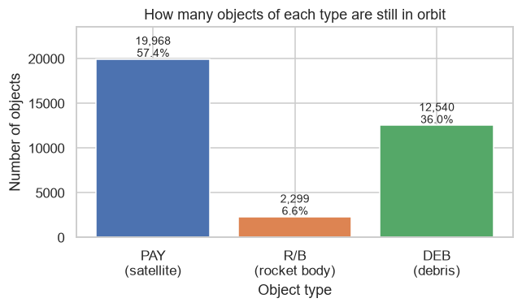

```python
fig, ax = plt.subplots(figsize=(6, 3.6))
order = ['PAY', 'R/B', 'DEB']
vals = df.OBJECT_TYPE.value_counts()[order]
bars = ax.bar(['PAY\n(satellite)', 'R/B\n(rocket body)', 'DEB\n(debris)'], vals.values,
              color=['#4C72B0', '#DD8452', '#55A868'])
for b, v in zip(bars, vals.values):
    ax.text(b.get_x() + b.get_width()/2, v + 250, f'{v:,}\n{v/len(df)*100:.1f}%',
            ha='center', fontsize=9)
ax.set_title('How many objects of each type are still in orbit')
ax.set_xlabel('Object type')
ax.set_ylabel('Number of objects')
ax.set_ylim(0, vals.max() * 1.18)
plt.tight_layout()
plt.savefig('../images/class_distribution.png', dpi=130)
plt.show()
```

### A quick look at the features

Before I choose features I want to see whether the orbit numbers actually differ per class. If the three types have the same orbits, no model will ever work.

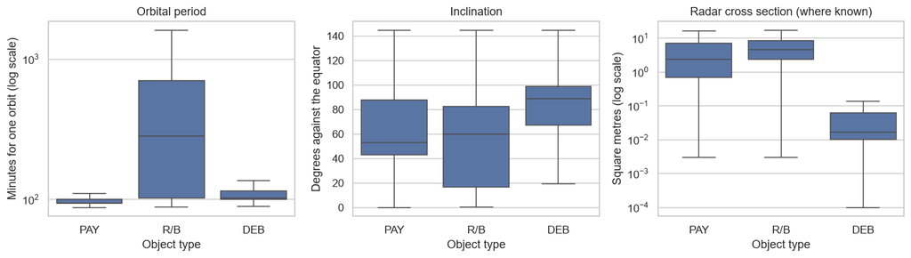

```python
df['LAUNCH_YEAR'] = pd.to_datetime(df.LAUNCH_DATE, errors='coerce').dt.year

fig, axes = plt.subplots(1, 3, figsize=(13, 3.8))
plot_df = df[df.OBJECT_TYPE.isin(order)]

sns.boxplot(data=plot_df, x='OBJECT_TYPE', y='PERIOD', order=order, ax=axes[0], showfliers=False)
axes[0].set_yscale('log')
axes[0].set_title('Orbital period')
axes[0].set_ylabel('Minutes for one orbit (log scale)')
axes[0].set_xlabel('Object type')

sns.boxplot(data=plot_df, x='OBJECT_TYPE', y='INCLINATION', order=order, ax=axes[1], showfliers=False)
axes[1].set_title('Inclination')
axes[1].set_ylabel('Degrees against the equator')
axes[1].set_xlabel('Object type')

sns.boxplot(data=plot_df.dropna(subset=['RCS']), x='OBJECT_TYPE', y='RCS', order=order, ax=axes[2], showfliers=False)
axes[2].set_yscale('log')
axes[2].set_title('Radar cross section (where known)')
axes[2].set_ylabel('Square metres (log scale)')
axes[2].set_xlabel('Object type')

plt.tight_layout()
plt.savefig('../images/feature_boxplots.png', dpi=130)
plt.show()
```

**Takeaway:** the three types really do look different. Rocket bodies sit in much wider orbits (long period), debris sits in high inclination orbits, and debris is tiny on radar while rocket bodies are the biggest. So there is signal here, good.

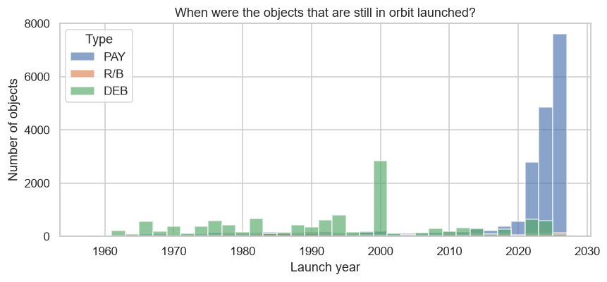

```python
fig, ax = plt.subplots(figsize=(8, 3.8))
for t, colour in zip(order, ['#4C72B0', '#DD8452', '#55A868']):
    ax.hist(df[df.OBJECT_TYPE == t].LAUNCH_YEAR, bins=np.arange(1957, 2028, 2),
            alpha=0.65, label=t, color=colour)
ax.set_title('When were the objects that are still in orbit launched?')
ax.set_xlabel('Launch year')
ax.set_ylabel('Number of objects')
ax.legend(title='Type')
plt.tight_layout()
plt.savefig('../images/launch_year.png', dpi=130)
plt.show()
```

**Takeaway:** almost all the recent objects are payloads. That is the mega constellation effect, SpaceX alone launches thousands of Starlink satellites. Debris and rocket bodies are spread out over the whole of space history. So launch year is going to be a strong feature.

### What the three types actually are

Before looking at numbers it helps to picture what I am trying to tell apart. The catalogue is only a table of numbers, there are no photos in it, so I drew a simple sketch of each type and put a real object from the data underneath it.

The story of one launch explains all three at once. A rocket lifts off carrying a satellite. The satellite is the **payload**, the part that does a job. The last stage of the rocket lets go of it and stays in orbit as an empty metal tube, the **rocket body**. Years later something explodes or two objects hit each other, and the pieces become **debris**.

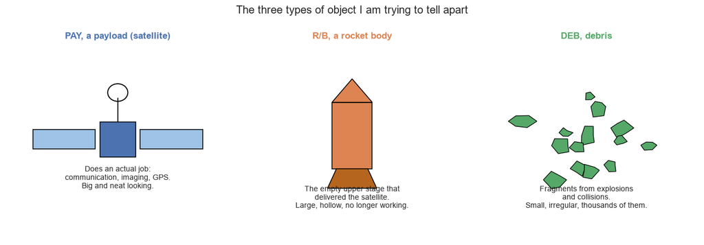

```python
from matplotlib.patches import Rectangle, Circle, Polygon

fig, axes = plt.subplots(1, 3, figsize=(12, 4.2))
for ax in axes:
    ax.set_xlim(0, 10)
    ax.set_ylim(0, 10)
    ax.axis('off')

# --- payload: a satellite body with two solar panels ---
ax = axes[0]
ax.add_patch(Rectangle((4.2, 4.2), 1.6, 1.8, facecolor='#4C72B0', edgecolor='black'))
ax.add_patch(Rectangle((1.2, 4.6), 2.8, 1.0, facecolor='#9ec3e6', edgecolor='black'))
ax.add_patch(Rectangle((6.0, 4.6), 2.8, 1.0, facecolor='#9ec3e6', edgecolor='black'))
ax.plot([5.0, 5.0], [6.0, 7.2], color='black', lw=1.2)
ax.add_patch(Circle((5.0, 7.5), 0.45, facecolor='none', edgecolor='black', lw=1.2))
ax.set_title('PAY, a payload (satellite)', fontsize=11, fontweight='bold', color='#4C72B0')
ax.text(5, 2.6, 'Does an actual job:\ncommunication, imaging, GPS.\nBig and neat looking.',
        ha='center', fontsize=9)

# --- rocket body: an empty upper stage ---
ax = axes[1]
ax.add_patch(Rectangle((4.1, 3.6), 1.8, 3.4, facecolor='#DD8452', edgecolor='black'))
ax.add_patch(Polygon([[4.1, 7.0], [5.9, 7.0], [5.0, 8.2]], facecolor='#DD8452', edgecolor='black'))
ax.add_patch(Polygon([[4.3, 3.6], [5.7, 3.6], [6.1, 2.6], [3.9, 2.6]],
                     facecolor='#b5651d', edgecolor='black'))
ax.set_title('R/B, a rocket body', fontsize=11, fontweight='bold', color='#DD8452')
ax.text(5, 1.6, 'The empty upper stage that\ndelivered the satellite.\nLarge, hollow, no longer working.',
        ha='center', fontsize=9)

# --- debris: irregular fragments ---
ax = axes[2]
rng = np.random.default_rng(1)
for _ in range(14):
    cx, cy = rng.uniform(2, 8), rng.uniform(3, 7.5)
    size = rng.uniform(0.18, 0.55)
    pts = [[cx + size * rng.uniform(0.4, 1.4) * np.cos(a),
            cy + size * rng.uniform(0.4, 1.4) * np.sin(a)]
           for a in np.linspace(0, 2 * np.pi, 6, endpoint=False)]
    ax.add_patch(Polygon(pts, facecolor='#55A868', edgecolor='black', lw=0.8))
ax.set_title('DEB, debris', fontsize=11, fontweight='bold', color='#55A868')
ax.text(5, 1.6, 'Fragments from explosions\nand collisions.\nSmall, irregular, thousands of them.',
        ha='center', fontsize=9)

fig.suptitle('The three types of object I am trying to tell apart', fontsize=13)
plt.tight_layout()
plt.savefig('../images/object_types.png', dpi=130)
plt.show()
```

```python
examples = pd.concat([
    df[df.OBJECT_NAME == 'ISS (ZARYA)'].head(1),
    df[(df.OBJECT_TYPE == 'R/B') & (df.OBJECT_NAME == 'FALCON 9 R/B')].nlargest(1, 'RCS'),
    df[df.OBJECT_NAME == 'FENGYUN 1C DEB'].head(1),
])[['OBJECT_NAME', 'OBJECT_TYPE', 'OWNER', 'LAUNCH_DATE',
    'PERIOD', 'INCLINATION', 'APOGEE', 'PERIGEE', 'RCS']]

print('One real object of each type, straight out of the catalogue:')
print(examples.to_string(index=False))
```

```
One real object of each type, straight out of the catalogue:
   OBJECT_NAME OBJECT_TYPE OWNER LAUNCH_DATE  PERIOD  INCLINATION  APOGEE  PERIGEE      RCS
   ISS (ZARYA)         PAY   ISS  1998-11-20   92.95        51.63   422.0    416.0 399.0524
  FALCON 9 R/B         R/B    US  2015-04-27  294.79        25.13 16405.0    183.0  44.4327
FENGYUN 1C DEB         DEB   PRC  1999-05-10  111.03        99.21  1706.0    843.0   0.0391
```

**Takeaway:** even these three rows already show the pattern the model will have to learn.

- The **ISS** is huge on radar (399 m2) and sits in a low, round orbit. Apogee 422 km and perigee 416 km are almost the same, so the orbit is nearly a circle.
- The **Falcon 9 rocket body** has a very stretched orbit. Perigee 183 km but apogee 16,405 km. It dropped its satellite off high up and fell back down on the other side of the orbit, so it is still swinging between those two heights. A period of 295 minutes instead of about 90 comes straight out of that.
- The **Fengyun 1C fragment** is tiny, 0.039 m2, and sits at 99 degrees inclination, which is a polar orbit.

That last one has a real story behind it, and it matters for my results later.

```python
fengyun = df.OBJECT_NAME.str.contains('FENGYUN 1C DEB', na=False).sum()
cosmos = df.OBJECT_NAME.str.contains('COSMOS 2251 DEB', na=False).sum()
print(f'pieces of FENGYUN 1C still in orbit : {fengyun:,}')
print(f'pieces of COSMOS 2251 still in orbit: {cosmos:,}')
print(f'together that is {(fengyun + cosmos) / (df.OBJECT_TYPE == "DEB").sum() * 100:.0f}% of all the debris in my data')
```

```
pieces of FENGYUN 1C still in orbit : 2,313
pieces of COSMOS 2251 still in orbit: 613
together that is 23% of all the debris in my data
```

**Takeaway:** in 2007 China shot down its own weather satellite, Fengyun 1C, as a missile test. That one event produced thousands of fragments and **2,313 of them are still up there today**, which is a big chunk of my entire debris class. Cosmos 2251 is the 2009 crash between a dead Russian satellite and an Iridium satellite.

So debris does not arrive one piece at a time. It arrives in **families**, hundreds or thousands of fragments from a single event, all in very similar orbits because they all started from the same place. I come back to this in the limitations, because it makes my test set easier than real life.

## 3. Preprocessing

### 3.1 Dropping the columns that cheat

This is the part of the project I spent the most time on. Several columns in SATCAT basically contain the answer. If I leave them in, the model gets 99% accuracy and I have learned nothing, because it is just reading the label from another column. This is called **data leakage**.

Let me show the evidence instead of just claiming it.

```python
name = df.OBJECT_NAME.str.upper()

print('Objects whose NAME contains "DEB":')
print(pd.crosstab(df.OBJECT_TYPE, name.str.contains('DEB', na=False)).loc[order])
print()
print('Objects whose NAME contains "R/B":')
print(pd.crosstab(df.OBJECT_TYPE, name.str.contains('R/B', na=False, regex=False)).loc[order])
print()
print('Objects that have an OPS_STATUS_CODE (percent per class):')
print((pd.crosstab(df.OBJECT_TYPE, df.OPS_STATUS_CODE.notna(), normalize='index') * 100).round(1).loc[order])
```

```
Objects whose NAME contains "DEB":
OBJECT_NAME  False  True
OBJECT_TYPE
PAY          19967      1
R/B           2299      0
DEB            212  12328

Objects whose NAME contains "R/B":
OBJECT_NAME  False  True
OBJECT_TYPE
PAY          19952     16
R/B             53   2246
DEB          12461     79

Objects that have an OPS_STATUS_CODE (percent per class):
OPS_STATUS_CODE  False  True
OBJECT_TYPE
PAY                7.2   92.8
R/B               99.9    0.1
DEB              100.0    0.0
```

So:

- **`OBJECT_NAME`** literally spells out the class. Almost every debris object has "DEB" in its name and almost every rocket body has "R/B". A model reading the name is doing text matching, not learning.
- **`OPS_STATUS_CODE`** is filled in for 93% of payloads and for basically nothing else. Only a working satellite has an operational status, so this column says "I am a payload".
- **`OBJECT_ID`** is the launch designator like `1998-067A`. The letter suffix counts up per launch, so a piece of debris from the 900th fragment has a long suffix and a payload usually has a single letter. Again a giveaway.
- **`NORAD_CAT_ID`** is a counter, so it is mostly just launch year in disguise, plus the same fragment numbering pattern.
- **`DECAY_DATE`** is empty for every row I kept, so it carries no information at all now.

All of these get dropped. `ORBIT_CENTER` also goes because after filtering it is `EA` for every row.

### 3.2 A column that turned out to be useless

I planned to use `ORBIT_TYPE` as a feature. When I actually checked it, it was not usable.

```python
print(df.ORBIT_TYPE.value_counts())
```

```
ORBIT_TYPE
ORB    34807
Name: count, dtype: int64
```

Every remaining object has `ORB`. A column with only one value cannot help a model separate anything, so I drop it too. Small lesson learned: check your features before you trust your plan.

### 3.3 The missing RCS values

`RCS` (radar cross section, how big the object looks to radar) is missing for a lot of rows. Before deciding what to do, I checked **whether it is missing at random**, because that changes the right answer.

```python
rcs_by_class = (pd.crosstab(df.OBJECT_TYPE, df.RCS.isna(), normalize='index') * 100).round(1)
rcs_by_class.columns = ['RCS known %', 'RCS missing %']
print('Missing RCS per class:')
print(rcs_by_class.loc[order])

df['DECADE'] = (df.LAUNCH_YEAR // 10) * 10
rcs_by_decade = (pd.crosstab(df.DECADE, df.RCS.isna(), normalize='index') * 100).round(0)
rcs_by_decade.columns = ['RCS known %', 'RCS missing %']
print()
print('Missing RCS per launch decade:')
print(rcs_by_decade)
```

```
Missing RCS per class:
             RCS known %  RCS missing %
OBJECT_TYPE
PAY                 17.6           82.4
R/B                 73.7           26.3
DEB                 74.6           25.4

Missing RCS per launch decade:
        RCS known %  RCS missing %
DECADE
1950           78.0           22.0
1960           92.0            8.0
1970           92.0            8.0
1980           88.0           12.0
1990           91.0            9.0
2000           88.0           12.0
2010           46.0           54.0
2020            0.0          100.0
```

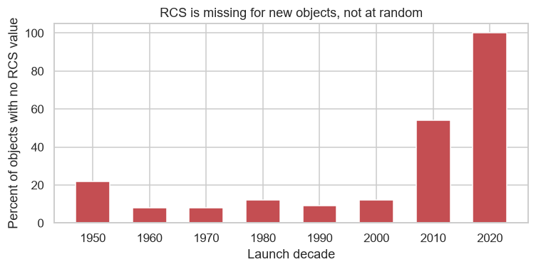

```python
fig, ax = plt.subplots(figsize=(7, 3.6))
ax.bar(rcs_by_decade.index.astype(str), rcs_by_decade['RCS missing %'], color='#C44E52', width=0.6)
ax.set_title('RCS is missing for new objects, not at random')
ax.set_xlabel('Launch decade')
ax.set_ylabel('Percent of objects with no RCS value')
ax.set_ylim(0, 105)
plt.tight_layout()
plt.savefig('../images/rcs_missing.png', dpi=130)
plt.show()
```

**Takeaway:** this was the most interesting thing I found while exploring. RCS is not missing randomly at all. It is missing for **100% of objects launched since 2020** and for almost none launched before 2010. CelesTrak simply does not publish a size for the newer objects yet.

It looks like RCS missing means "it is a satellite" (82% of payloads have no RCS), but that is a side effect: most new objects are satellites, and all new objects have no RCS. The real driver is age, not type.

**What I do about it:** I fill the missing values with the median of the training set, and I add an extra column `rcs_missing` that is 1 when the value was filled in. That way the network knows the number is a guess instead of silently believing a fake value. Later in the baseline section I check whether that flag actually matters.

### 3.4 Rows with no orbit data

```python
before = len(df)
df = df.dropna(subset=['PERIOD', 'INCLINATION', 'APOGEE', 'PERIGEE', 'LAUNCH_YEAR'])
print(f'dropped {before - len(df)} rows with no orbit data ({(before-len(df))/before*100:.1f}%)')
print(f'{len(df)} rows left for modelling')
df = df.reset_index(drop=True)
```

```
dropped 333 rows with no orbit data (1.0%)
34474 rows left for modelling
```

### 3.5 Building the feature table

**Numeric features.** Period, apogee and perigee cover an enormous range. Perigee can be 300 km and apogee can be 640,000 km. If I feed those in raw, the huge values dominate everything. So I take `log10` of them first, which squashes the range without losing the ordering. RCS gets the same treatment because it goes from 0.0001 to 830 m2.

**Categorical features.** `OWNER` has 106 different values and `LAUNCH_SITE` has 34. Most of them appear only a handful of times. Making a column for each would add a lot of nearly empty columns, which is a good way to overfit. So I keep the categories that appear at least 100 times **in the training set** and call the rest `OTHER`, then one hot encode.

One hot encoding means: instead of one column "OWNER" with text in it, I make one column per owner that is 1 or 0. A neural network can only work with numbers, and if I just numbered the owners 1 to 106 the network would think owner 50 is somehow bigger than owner 10.

```python
def build_features(data, top_owners, top_sites):
    """Turn the cleaned catalogue into a numeric feature table."""
    X = pd.DataFrame(index=data.index)

    # numbers, log scaled where the range is huge
    X['log_period']  = np.log10(data.PERIOD)
    X['inclination'] = data.INCLINATION
    X['log_apogee']  = np.log10(data.APOGEE + 1)
    X['log_perigee'] = np.log10(data.PERIGEE + 1)
    X['launch_year'] = data.LAUNCH_YEAR
    X['rcs_missing'] = data.RCS.isna().astype(int)
    X['log_rcs']     = np.log10(data.RCS)      # stays NaN where missing, filled after the split

    # categories, rare ones grouped into OTHER
    owner = data.OWNER.where(data.OWNER.isin(top_owners), 'OTHER')
    site  = data.LAUNCH_SITE.where(data.LAUNCH_SITE.isin(top_sites), 'OTHER')

    return pd.concat([
        X,
        pd.get_dummies(owner, prefix='own').astype(float),
        pd.get_dummies(site,  prefix='site').astype(float),
    ], axis=1)
```

### 3.6 Splitting the data

I split into **70% train, 15% validation and 15% test**, and I use `stratify` so all three splits have the same class mix. Without that, a random split could easily give the test set too few rocket bodies to measure anything.

What each part is for:

- **Train** is what the network learns from.
- **Validation** is what I look at while tuning. Early stopping watches it and I compare experiments on it.
- **Test** I touch exactly once, at the very end. If I tuned on the test set, my final number would be optimistic and meaningless.

- the list of common owners and launch sites is taken from the **training set only**
- the median used to fill missing RCS is the **training median**
- the scaler is fitted on the **training set only**

If I computed any of those on the full data, information from validation and test would leak into training and my scores would be too good.

```python
from sklearn.model_selection import train_test_split
from sklearn.preprocessing import StandardScaler

CLASSES = ['PAY', 'R/B', 'DEB']
LABEL_TO_INT = {c: i for i, c in enumerate(CLASSES)}


def make_dataset(data, seed=SEED):
    """Split, encode and scale. Returns a dict with the ready to use arrays."""
    y = data.OBJECT_TYPE.map(LABEL_TO_INT).values
    idx = np.arange(len(data))

    i_train, i_rest = train_test_split(idx, test_size=0.30, stratify=y, random_state=seed)
    i_val, i_test   = train_test_split(i_rest, test_size=0.50, stratify=y[i_rest], random_state=seed)

    train_rows = data.iloc[i_train]
    top_owners = train_rows.OWNER.value_counts()[lambda s: s >= 100].index.tolist()
    top_sites  = train_rows.LAUNCH_SITE.value_counts()[lambda s: s >= 100].index.tolist()

    X = build_features(data, top_owners, top_sites)
    X['log_rcs'] = X.log_rcs.fillna(X.iloc[i_train].log_rcs.median())

    scaler = StandardScaler().fit(X.iloc[i_train].values)

    out = {'columns': list(X.columns), 'n_features': X.shape[1],
           'top_owners': top_owners, 'top_sites': top_sites}
    for part, rows in [('train', i_train), ('val', i_val), ('test', i_test)]:
        out['X_' + part] = scaler.transform(X.iloc[rows].values)
        out['y_' + part] = y[rows]
    return out


data = make_dataset(df)

print(f"features: {data['n_features']}")
print(f"train {len(data['y_train'])} | validation {len(data['y_val'])} | test {len(data['y_test'])}")
print(f"owners kept: {len(data['top_owners'])} | launch sites kept: {len(data['top_sites'])}")
print()
print('class mix per split (%):')
mix = pd.DataFrame({p: pd.Series(data['y_' + p]).value_counts(normalize=True) * 100
                    for p in ['train', 'val', 'test']}).round(1)
mix.index = [CLASSES[i] for i in mix.index]
print(mix)
```

```
features: 31
train 24131 | validation 5171 | test 5172
owners kept: 9 | launch sites kept: 13

class mix per split (%):
     train   val  test
PAY   57.6  57.6  57.6
DEB   35.9  35.9  35.9
R/B    6.5   6.5   6.5
```

**Takeaway:** 31 features and the class mix is identical in all three splits, so the stratified split did its job. Scaling means every feature now has mean 0 and standard deviation 1, which matters for neural networks because otherwise `launch_year` (around 2000) would swamp `inclination` (0 to 180) just because its numbers are bigger.

### 3.7 Do my features repeat each other?

Now that the features exist I should check whether some of them are basically saying the same thing twice. Two features that always move together carry one piece of information, not two.

The measure for this is **correlation**. It runs from +1 to -1:

- **+1** means when one goes up the other always goes up too
- **0** means they have nothing to do with each other
- **-1** means when one goes up the other always goes down

I only check this on the **training set**, same rule as everywhere else, and only for the seven number features. The one hot columns are all 0 or 1 so correlation does not say much about them.

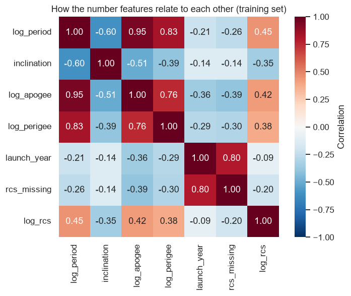

```python
numeric_cols = ['log_period', 'inclination', 'log_apogee', 'log_perigee',
                'launch_year', 'rcs_missing', 'log_rcs']
positions = [data['columns'].index(c) for c in numeric_cols]
corr = pd.DataFrame(data['X_train'][:, positions], columns=numeric_cols).corr()

fig, ax = plt.subplots(figsize=(7, 5.5))
sns.heatmap(corr, annot=True, fmt='.2f', cmap='RdBu_r', center=0, vmin=-1, vmax=1,
            square=True, cbar_kws={'label': 'Correlation'}, ax=ax)
ax.set_title('How the number features relate to each other (training set)')
plt.tight_layout()
plt.savefig('../images/feature_correlation.png', dpi=130)
plt.show()
```

```python
pairs = (corr.abs()
         .where(np.triu(np.ones(corr.shape), 1).astype(bool))
         .stack().sort_values(ascending=False))

print('The strongest relationships between my features:')
for (a, b), _ in pairs.head(5).items():
    print(f'  {a:12s} and {b:12s}  correlation {corr.loc[a, b]:+.2f}')
```

```
The strongest relationships between my features:
  log_period   and log_apogee    correlation +0.95
  log_period   and log_perigee   correlation +0.83
  launch_year  and rcs_missing   correlation +0.80
  log_apogee   and log_perigee   correlation +0.76
  log_period   and inclination   correlation -0.60
```

**Takeaway:** two pairs stand out, and both of them have a real world reason behind them.

**1. Period and apogee, correlation +0.95.** These are almost the same feature. That is not a coincidence in the data, it is physics. Kepler's third law says how long an orbit takes is decided by how big the orbit is. So if I know how high something flies, I already know roughly how long it takes to go around. Perigee is in the same family at +0.83.

**2. Launch year and rcs_missing, correlation +0.80.** This is the number that proves what I suspected back in section 3.3. The flag for "RCS was missing" is 80% the same thing as "this was launched recently". It is not secret extra knowledge, it is launch year wearing a hat.

**Does this hurt?** For a neural network, not really. Unlike a linear model, it does not fall apart when two inputs overlap, it just learns smaller weights for both. That is also exactly what I measured in section 4: removing the rcs_missing flag changed macro F1 by 0.007, which is nothing.

**So why check at all?** Two reasons. It tells me my 31 features are not 31 independent facts, more like 25, so I should not expect a bigger network to keep finding new things forever. And it warns me not to say things like "period is the most important feature", because apogee would do almost the same job on its own.

**One more thing worth noticing:** period and inclination have a correlation of -0.60. Things in high, slow orbits tend to sit near the equator, and things in fast low orbits are more often in steep polar orbits. That is not physics forcing it, that is just how humans use space.

## 4. Baselines

Before building a neural network I need something to compare against. A fancy model that cannot beat a dumb model is not worth anything. I use two baselines:

1. **Majority class.** Always answer PAY. This shows what accuracy is worth nothing.
2. **Logistic regression.** A simple, fast, linear model from scikit learn. If the neural network cannot beat this, the extra complexity is not justified.

### How I measure "good", in plain words

Accuracy is just the share of answers that were right. It is the obvious choice and it is misleading here. Rocket bodies are only 6.5% of the data, so a model can ignore them completely and still score well. I need something that notices that.

Three words I use from here on. Imagine the model just said "this is a rocket body":

- **Precision** answers *when it says R/B, how often is it right?* Low precision means it cries wolf.
- **Recall** answers *of all the real rocket bodies out there, how many did it find?* Low recall means it misses things.
- **F1** squashes those two into one number. It is only high when both are decent, so a model cannot cheat it by being good at one and terrible at the other.

You usually have to trade one for the other. A model that shouts "rocket body" at everything has perfect recall and awful precision. A model that only says it when completely certain has the opposite problem.

**Macro F1** is the F1 of each of the three classes, averaged with equal weight. Equal weight is the important bit: the tiny rocket body class counts exactly as much as the huge payload class, so a model that ignores rocket bodies gets punished hard. That is the number I use to compare everything in this notebook.

```python
from sklearn.dummy import DummyClassifier
from sklearn.linear_model import LogisticRegression
from sklearn.metrics import accuracy_score, f1_score, classification_report, confusion_matrix

def score(y_true, y_pred):
    return accuracy_score(y_true, y_pred), f1_score(y_true, y_pred, average='macro')

majority = DummyClassifier(strategy='most_frequent').fit(data['X_train'], data['y_train'])
logreg   = LogisticRegression(max_iter=2000, random_state=SEED).fit(data['X_train'], data['y_train'])

rows = []
for name, model in [('Majority class', majority), ('Logistic regression', logreg)]:
    acc, f1 = score(data['y_val'], model.predict(data['X_val']))
    rows.append({'model': name, 'val accuracy': round(acc, 3), 'val macro F1': round(f1, 3)})

baseline_results = pd.DataFrame(rows)
print(baseline_results.to_string(index=False))
```

```
              model  val accuracy  val macro F1
     Majority class         0.576         0.244
Logistic regression         0.901         0.755
```

```python
print('Logistic regression, per class, on the validation set:')
print(classification_report(data['y_val'], logreg.predict(data['X_val']),
                            target_names=CLASSES, digits=3))
```

```
Logistic regression, per class, on the validation set:
              precision    recall  f1-score   support

         PAY      0.916     0.938     0.927      2980
         R/B      0.585     0.318     0.412       337
         DEB      0.907     0.947     0.926      1854

    accuracy                          0.901      5171
   macro avg      0.802     0.734     0.755      5171
weighted avg      0.891     0.901     0.893      5171
```

**Takeaway:** guessing PAY every time gives 58% accuracy but a macro F1 of only 0.24, which shows exactly why accuracy alone is a bad metric here.

Logistic regression already does well: 90% accuracy. But look at the R/B row. Recall is only 0.32, so it **misses two out of three rocket bodies**. It found the easy classes and mostly gave up on the rare one. That is the gap I want the neural network to close.

### Does the rcs_missing flag actually help?

Earlier I added a flag column saying "this RCS value was filled in". I worried it might be a shortcut that makes the model look better than it is. Quick check: train the same logistic regression without it.

```python
keep_cols = [i for i, c in enumerate(data['columns']) if c != 'rcs_missing']
logreg_noflag = LogisticRegression(max_iter=2000, random_state=SEED).fit(
    data['X_train'][:, keep_cols], data['y_train'])

acc_with, f1_with = score(data['y_val'], logreg.predict(data['X_val']))
acc_without, f1_without = score(data['y_val'], logreg_noflag.predict(data['X_val'][:, keep_cols]))

print(f'with rcs_missing flag   : accuracy {acc_with:.3f}  macro F1 {f1_with:.3f}')
print(f'without rcs_missing flag: accuracy {acc_without:.3f}  macro F1 {f1_without:.3f}')
```

```
with rcs_missing flag   : accuracy 0.901  macro F1 0.755
```

```
without rcs_missing flag: accuracy 0.899  macro F1 0.748
```

**Takeaway:** almost no difference. So the flag is not a cheat code. That makes sense with what I found in section 3.3: the flag says "launched after 2020", and `launch_year` is already a feature, so the model was not missing anything. I keep the flag because it is honest about which values were guessed, but nothing depends on it.

## 5. The neural network

### How I think about it

A neural network here is a stack of layers. Each layer takes the numbers from the layer before, multiplies them by weights, adds a bias and passes the result through an activation function. Training means: make a guess, measure how wrong it is, and nudge every weight a little in the direction that makes the error smaller. Do that thousands of times.

My choices and the reason for each:

| Choice | What I picked | Why |
| --- | --- | --- |
| Input | 31 numbers | one per feature after scaling and one hot encoding |
| Hidden layers | Dense + ReLU | ReLU is the normal default, it is fast and does not suffer from vanishing gradients the way sigmoid does |
| Output | 3 neurons + softmax | one per class, softmax turns the outputs into probabilities that add up to 1 |
| Loss | sparse categorical crossentropy | the standard loss for multi class problems, "sparse" because my labels are 0/1/2 instead of one hot |
| Optimiser | Adam | adapts the step size per weight, works well without much tuning |
| Batch size | 256 | big enough to be fast, small enough to still update often |
| Early stopping | patience 8 on validation loss | stops when the validation loss has not improved for 8 epochs and puts back the best weights, so I do not have to guess the right number of epochs |

### Class weights

```python
from sklearn.utils.class_weight import compute_class_weight


def class_weights_for(y_train):
    """Weight each class by how rare it is, so the rare classes are not ignored."""
    weights = compute_class_weight('balanced', classes=np.arange(3), y=y_train)
    return dict(enumerate(weights))


weights = class_weights_for(data['y_train'])

print('class weights used in training:')
for i, c in enumerate(CLASSES):
    print(f'  {c:4s} {weights[i]:.2f}')
```

```
class weights used in training:
  PAY  0.58
  R/B  5.12
  DEB  0.93
```

### One function for every experiment

To compare hyperparameters fairly, every model has to be built the same way. So I write one `build_model(params)` function and every experiment later calls it with a different dictionary. Nothing else changes between runs, which means any difference I see really comes from the hyperparameter and not from me accidentally changing something else.

```python
def build_model(params, n_features, n_classes=3, seed=SEED):
    """Build one MLP. params: hidden_layers (list of ints), learning_rate, dropout."""
    keras.utils.set_random_seed(seed)          # same starting weights every time

    model = keras.Sequential(name='mlp')
    model.add(keras.layers.Input(shape=(n_features,)))
    for units in params['hidden_layers']:
        model.add(keras.layers.Dense(units, activation='relu'))
        if params.get('dropout', 0) > 0:
            model.add(keras.layers.Dropout(params['dropout']))
    model.add(keras.layers.Dense(n_classes, activation='softmax'))

    model.compile(
        optimizer=keras.optimizers.Adam(learning_rate=params['learning_rate']),
        loss='sparse_categorical_crossentropy',
        metrics=['accuracy'])
    return model


def train_model(params, ds, seed=SEED, max_epochs=150, patience=8, use_class_weights=True):
    """Train one model and return it together with its history.

    The class weights are always taken from the dataset that is passed in, so an
    experiment on a different dataset still gets the weights that belong to it.
    """
    model = build_model(params, ds['n_features'], seed=seed)
    stop = keras.callbacks.EarlyStopping(monitor='val_loss', patience=patience,
                                         restore_best_weights=True)
    history = model.fit(
        ds['X_train'], ds['y_train'],
        validation_data=(ds['X_val'], ds['y_val']),
        epochs=max_epochs, batch_size=256,
        class_weight=class_weights_for(ds['y_train']) if use_class_weights else None,
        callbacks=[stop], verbose=0)
    return model, history
```

### First run

Before experimenting I train one model with sensible default settings to check the whole thing works: two hidden layers of 64 and 32 neurons, learning rate 0.001, no dropout.

```python
DEFAULT_PARAMS = {'hidden_layers': [64, 32], 'learning_rate': 0.001, 'dropout': 0.0}

first_model, first_history = train_model(DEFAULT_PARAMS, data)
first_model.summary()

val_pred = first_model.predict(data['X_val'], verbose=0).argmax(axis=1)
acc, f1 = score(data['y_val'], val_pred)
n_epochs = len(first_history.history['loss'])
print()
print(f'stopped after {n_epochs} epochs')
print(f'validation accuracy {acc:.3f} | macro F1 {f1:.3f}')
```

[output not shown]

```
Model: "mlp"
```

```
┏━━━━━━━━━━━━━━━━━━━━━━━━━━━━━━━━━┳━━━━━━━━━━━━━━━━━━━━━━━━┳━━━━━━━━━━━━━━━┓
┃ Layer (type)                    ┃ Output Shape           ┃       Param # ┃
┡━━━━━━━━━━━━━━━━━━━━━━━━━━━━━━━━━╇━━━━━━━━━━━━━━━━━━━━━━━━╇━━━━━━━━━━━━━━━┩
│ dense (Dense)                   │ (None, 64)             │         2,048 │
├─────────────────────────────────┼────────────────────────┼───────────────┤
│ dense_1 (Dense)                 │ (None, 32)             │         2,080 │
├─────────────────────────────────┼────────────────────────┼───────────────┤
│ dense_2 (Dense)                 │ (None, 3)              │            99 │
└─────────────────────────────────┴────────────────────────┴───────────────┘
```

```
 Total params: 12,683 (49.55 KB)
```

```
 Trainable params: 4,227 (16.51 KB)
```

```
 Non-trainable params: 0 (0.00 B)
```

```
 Optimizer params: 8,456 (33.04 KB)
```

```
stopped after 106 epochs
validation accuracy 0.930 | macro F1 0.863
```

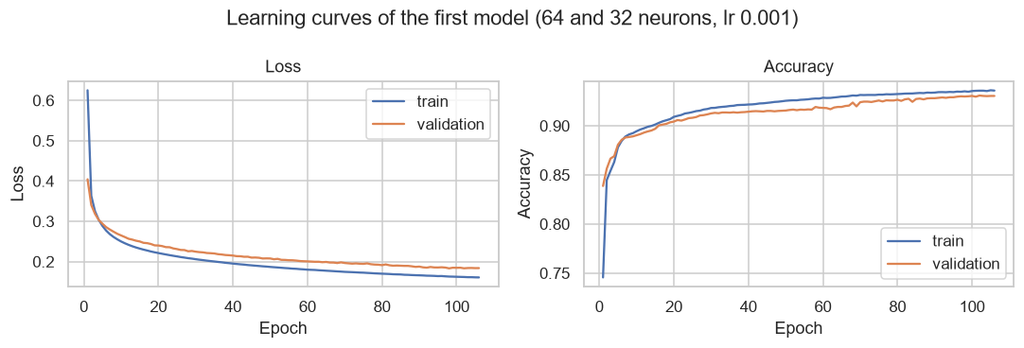

```python
def plot_curves(history, title, filename=None):
    """Draw training and validation loss and accuracy for one run."""
    h = history.history
    epochs = range(1, len(h['loss']) + 1)
    fig, ax = plt.subplots(1, 2, figsize=(10, 3.4))
    ax[0].plot(epochs, h['loss'], label='train')
    ax[0].plot(epochs, h['val_loss'], label='validation')
    ax[0].set_title('Loss')
    ax[0].set_xlabel('Epoch')
    ax[0].set_ylabel('Loss')
    ax[0].legend()
    ax[1].plot(epochs, h['accuracy'], label='train')
    ax[1].plot(epochs, h['val_accuracy'], label='validation')
    ax[1].set_title('Accuracy')
    ax[1].set_xlabel('Epoch')
    ax[1].set_ylabel('Accuracy')
    ax[1].legend()
    fig.suptitle(title)
    plt.tight_layout()
    if filename:
        plt.savefig(filename, dpi=130)
    plt.show()


plot_curves(first_history, 'Learning curves of the first model (64 and 32 neurons, lr 0.001)',
            '../images/first_model_curves.png')
```

```python
print('First model, per class, on the validation set:')
print(classification_report(data['y_val'], val_pred, target_names=CLASSES, digits=3))
```

```
First model, per class, on the validation set:
              precision    recall  f1-score   support

         PAY      0.994     0.904     0.947      2980
         R/B      0.529     0.935     0.676       337
         DEB      0.965     0.970     0.967      1854

    accuracy                          0.930      5171
   macro avg      0.829     0.936     0.863      5171
weighted avg      0.953     0.930     0.937      5171
```

**Takeaway:** the network beats logistic regression straight away, and the big win is on rocket bodies. Recall for R/B jumps from 0.32 to around 0.94, so the class weights worked. The price is precision: many things the model calls a rocket body are not one. In other words it now says "rocket body" too easily. I come back to this trade in the discussion.

The learning curves show train and validation loss going down together and staying close, so at this size the model is not overfitting yet.

### The two ways training can go wrong

Before I start changing settings I want to be clear about what I am looking for in a learning curve, because almost every choice later comes back to these two problems.

**Underfitting** means the model is too weak, or trained too briefly. It never picked up the pattern. You see it when the training loss and the validation loss are **both high and sitting close together**. The model is equally bad everywhere, which means it never learned much.

**Overfitting** means the model started memorising the training rows instead of learning the general rule. You see it when the **training loss keeps falling but the validation loss turns around and starts rising**. It is getting better at the data it has already seen and worse at everything else, which is the opposite of useful.

Rather than just describe this, I want to see it. So I run my biggest network twice with early stopping switched off, for a fixed 150 epochs:

- **Left:** on the full training set, 24,131 objects.
- **Right:** on only 1,000 objects. Less data to learn from makes memorising much easier, so this is the usual way to force overfitting on purpose.

```python
BIG = {'hidden_layers': [256, 128, 64], 'learning_rate': 0.001, 'dropout': 0.0}

def train_without_early_stopping(X, y, epochs=150, batch_size=256):
    """Train for a fixed number of epochs with nothing to stop it going too far."""
    model = build_model(BIG, data['n_features'])
    return model.fit(X, y, validation_data=(data['X_val'], data['y_val']),
                     epochs=epochs, batch_size=batch_size,
                     class_weight=class_weights_for(y), verbose=0).history

# the full training set
full_history = train_without_early_stopping(data['X_train'], data['y_train'])

# a deliberately tiny slice of it
rng = np.random.default_rng(SEED)
small = rng.choice(len(data['X_train']), 1000, replace=False)
small_history = train_without_early_stopping(data['X_train'][small], data['y_train'][small],
                                             batch_size=64)

for name, h in [('full training set (24,131 rows)', full_history), ('only 1,000 rows', small_history)]:
    best = int(np.argmin(h['val_loss']))
    print(f'{name}:')
    print(f'    best validation loss {h["val_loss"][best]:.4f} at epoch {best + 1}')
    print(f'    at epoch 150: training loss {h["loss"][-1]:.4f}, validation loss {h["val_loss"][-1]:.4f}')
    print(f'    validation loss got {h["val_loss"][-1] - h["val_loss"][best]:+.4f} worse after its best point')
```

```
full training set (24,131 rows):
    best validation loss 0.1628 at epoch 146
    at epoch 150: training loss 0.0918, validation loss 0.1682
    validation loss got +0.0054 worse after its best point
only 1,000 rows:
    best validation loss 0.2827 at epoch 16
    at epoch 150: training loss 0.0687, validation loss 0.5239
    validation loss got +0.2413 worse after its best point
```

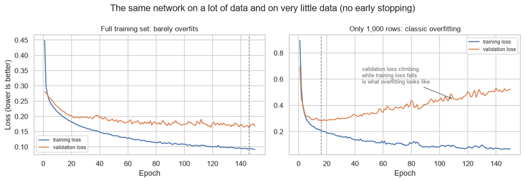

```python
fig, axes = plt.subplots(1, 2, figsize=(11.5, 4))
panels = [(full_history, 'Full training set: barely overfits'),
          (small_history, 'Only 1,000 rows: classic overfitting')]

for ax, (h, title) in zip(axes, panels):
    epochs = range(1, len(h['loss']) + 1)
    best = int(np.argmin(h['val_loss']))
    ax.plot(epochs, h['loss'], label='training loss')
    ax.plot(epochs, h['val_loss'], label='validation loss')
    ax.axvline(best + 1, color='grey', ls='--', lw=1)
    ax.set_title(title, fontsize=11)
    ax.set_xlabel('Epoch')
    ax.legend(fontsize=8)

axes[0].set_ylabel('Loss (lower is better)')
axes[1].annotate('validation loss climbing\nwhile training loss falls\nis what overfitting looks like',
                 xy=(110, small_history['val_loss'][109]),
                 xytext=(45, small_history['val_loss'][109] + 0.12),
                 arrowprops=dict(arrowstyle='->', color='dimgrey'), fontsize=8.5, color='dimgrey')
fig.suptitle('The same network on a lot of data and on very little data (no early stopping)')
plt.tight_layout()
plt.savefig('../images/overfitting_demo.png', dpi=130)
plt.show()
```

**Takeaway:** the right hand chart is the textbook picture. Validation loss drops for about 16 epochs, hits its best point, then climbs and keeps climbing, while the training loss slides all the way down towards zero. By epoch 150 the network knows those 1,000 objects almost perfectly and has become noticeably worse at everything else. That is memorising, not learning. The dashed line is where early stopping would have pulled it out.

**But the left hand chart surprised me, and it is the more useful result.** On the full training set the same network hardly overfits at all across 150 epochs. The two lines drift apart a little and that is it. The validation loss does not run away.

The reason is simply that 24,131 examples is a lot for a problem with 31 features. There are too many different objects for the network to memorise them one by one, so the cheapest thing it can do is actually learn the rule.

**This explains something that comes later.** In Experiment C I add dropout to fight overfitting and it makes the model worse. The left hand chart is why: on the full data there was not much overfitting to fight. Dropout was a cure for an illness this model did not really have, so all it did was take away capacity the network was still using.

**And it explains why early stopping is enough here.** It quietly picks the best epoch for me, so I never have to guess how long to train, and that turned out to be all the protection this model needed.

## 6. Hyperparameter experiments

Now the main part of the assignment. I test two hyperparameters properly and add a third experiment plus a bonus one:

[output not shown]

I only change **one thing at a time**. If I changed two, I would not know which one caused the difference.

> **Note on running time.** Each of the four experiment cells below trains 6 to 12 networks, so it takes roughly 2 to 3 minutes. Training itself is silent (`verbose=0`) to keep the notebook readable, so each run prints one short line when it finishes. If you see those lines appearing, it is working. The whole notebook takes about 12 minutes on a laptop without a GPU.

### Making the results trustworthy

A neural network starts with random weights, so two runs with the same settings give slightly different numbers. If I ran each setting once, I could easily call a setting "better" when it was just lucky. So I run **every setting three times with three different seeds** and report the average and the spread. The spread tells me whether a difference is real or just noise.

```python
import time

SEEDS = [42, 7, 2024]


def run_experiment(name, setting, params, ds=None, seeds=SEEDS, use_class_weights=True):
    """Train the same settings once per seed and return the averaged result plus the histories."""
    ds = data if ds is None else ds
    accs, f1s, epochs, histories = [], [], [], []

    for seed in seeds:
        started = time.time()
        model, history = train_model(params, ds, seed=seed, use_class_weights=use_class_weights)
        pred = model.predict(ds['X_val'], verbose=0).argmax(axis=1)
        acc, f1 = score(ds['y_val'], pred)
        accs.append(acc)
        f1s.append(f1)
        epochs.append(len(history.history['loss']))
        histories.append(history)
        # one short line per run, so I can see it is still working during the long cells
        print(f'  {setting:22s} seed {seed:<5d} acc {acc:.4f}  macro F1 {f1:.4f}'
              f'  ({epochs[-1]} epochs, {time.time() - started:.0f}s)', flush=True)

    return {
        'experiment': name,
        'setting': setting,
        'val accuracy': np.mean(accs),
        'acc spread': np.std(accs),
        'val macro F1': np.mean(f1s),
        'F1 spread': np.std(f1s),
        'epochs': int(np.mean(epochs)),
        'histories': histories,
        'params': params,
    }


def results_table(runs):
    """Turn a list of runs into a readable table."""
    table = pd.DataFrame([{k: r[k] for k in
                           ['experiment', 'setting', 'val accuracy', 'acc spread',
                            'val macro F1', 'F1 spread', 'epochs']} for r in runs])
    return table.round({'val accuracy': 4, 'acc spread': 4, 'val macro F1': 4, 'F1 spread': 4})


def plot_experiment(runs, title, filename, seed_index=0):
    """One panel per setting showing train and validation loss of the first seed."""
    fig, axes = plt.subplots(1, len(runs), figsize=(3.4 * len(runs), 3.2), sharey=True)
    axes = np.atleast_1d(axes)
    for ax, run in zip(axes, runs):
        h = run['histories'][seed_index].history
        epochs = range(1, len(h['loss']) + 1)
        ax.plot(epochs, h['loss'], label='train')
        ax.plot(epochs, h['val_loss'], label='validation')
        ax.set_title(f"{run['setting']}\nval acc {run['val accuracy']:.3f}", fontsize=10)
        ax.set_xlabel('Epoch')
    axes[0].set_ylabel('Loss')
    axes[0].legend(fontsize=8)
    fig.suptitle(title)
    plt.tight_layout()
    plt.savefig(filename, dpi=130)
    plt.show()
```

### Experiment A: learning rate

The learning rate decides how big a step the optimiser takes each time it updates the weights. Too big and it jumps over the good solution and never settles. Too small and it crawls, and early stopping may cut it off before it arrives. I test four values, each one ten times smaller than the last.

```python
LEARNING_RATES = [0.1, 0.01, 0.001, 0.0001]

start = time.time()
lr_runs = [run_experiment('learning rate', f'lr = {lr}',
                          {'hidden_layers': [64, 32], 'learning_rate': lr, 'dropout': 0.0})
           for lr in LEARNING_RATES]
print(f'done in {time.time() - start:.0f} seconds')
print()
print(results_table(lr_runs).to_string(index=False))
```

```
  lr = 0.1               seed 42    acc 0.7701  macro F1 0.6940  (10 epochs, 2s)
```

```
  lr = 0.1               seed 7     acc 0.7177  macro F1 0.6571  (9 epochs, 2s)
```

```
  lr = 0.1               seed 2024  acc 0.7331  macro F1 0.6640  (11 epochs, 2s)
```

```
  lr = 0.01              seed 42    acc 0.9257  macro F1 0.8565  (24 epochs, 4s)
```

```
  lr = 0.01              seed 7     acc 0.9431  macro F1 0.8817  (60 epochs, 10s)
```

```
  lr = 0.01              seed 2024  acc 0.9377  macro F1 0.8742  (62 epochs, 10s)
```

```
  lr = 0.001             seed 42    acc 0.9298  macro F1 0.8634  (106 epochs, 16s)
```

```
  lr = 0.001             seed 7     acc 0.9387  macro F1 0.8769  (150 epochs, 23s)
```

```
  lr = 0.001             seed 2024  acc 0.9404  macro F1 0.8803  (150 epochs, 23s)
```

```
  lr = 0.0001            seed 42    acc 0.9047  macro F1 0.8282  (150 epochs, 23s)
```

```
  lr = 0.0001            seed 7     acc 0.9105  macro F1 0.8368  (150 epochs, 23s)
```

```
  lr = 0.0001            seed 2024  acc 0.9099  macro F1 0.8363  (150 epochs, 23s)
```

```
done in 160 seconds

   experiment     setting  val accuracy  acc spread  val macro F1  F1 spread  epochs
learning rate    lr = 0.1        0.7403      0.0220        0.6717     0.0160      10
learning rate   lr = 0.01        0.9355      0.0073        0.8708     0.0105      48
learning rate  lr = 0.001        0.9363      0.0047        0.8735     0.0073     135
learning rate lr = 0.0001        0.9083      0.0026        0.8338     0.0039     150
```

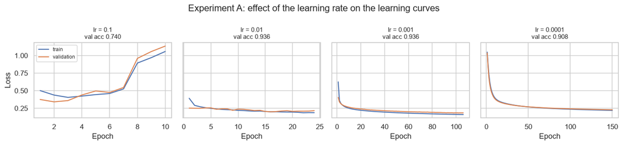

```python
plot_experiment(lr_runs, 'Experiment A: effect of the learning rate on the learning curves',
                '../images/exp_learning_rate.png')
```

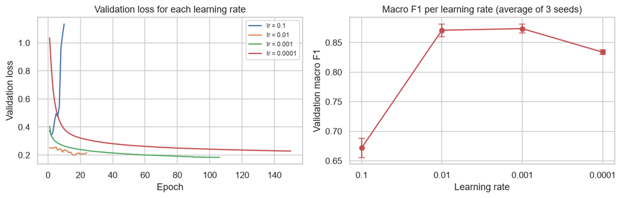

```python
fig, ax = plt.subplots(1, 2, figsize=(11, 3.6))
for run in lr_runs:
    h = run['histories'][0].history
    ax[0].plot(range(1, len(h['val_loss']) + 1), h['val_loss'], label=run['setting'])
ax[0].set_title('Validation loss for each learning rate')
ax[0].set_xlabel('Epoch')
ax[0].set_ylabel('Validation loss')
ax[0].legend(fontsize=8)

table = results_table(lr_runs)
ax[1].errorbar(range(len(table)), table['val macro F1'], yerr=table['F1 spread'],
               marker='o', capsize=4, color='#C44E52')
ax[1].set_xticks(range(len(table)))
ax[1].set_xticklabels([str(lr) for lr in LEARNING_RATES])
ax[1].set_title('Macro F1 per learning rate (average of 3 seeds)')
ax[1].set_xlabel('Learning rate')
ax[1].set_ylabel('Validation macro F1')
plt.tight_layout()
plt.savefig('../images/exp_learning_rate_summary.png', dpi=130)
plt.show()
```

### Experiment B: network size

Now I keep the learning rate at 0.001 and change how many neurons the network has. More neurons means more weights, so the network can learn more complicated patterns, but it can also start memorising the training data instead of learning the general rule.

| Name | Layers | Roughly how many weights |
| --- | --- | --- |
| small | 16 | about 550 |
| medium | 64, 32 | about 4,200 |
| large | 256, 128, 64 | about 50,000 |

```python
SIZES = {
    'small (16)':            [16],
    'medium (64, 32)':       [64, 32],
    'large (256, 128, 64)':  [256, 128, 64],
}

start = time.time()
size_runs = [run_experiment('network size', name,
                            {'hidden_layers': layers, 'learning_rate': 0.001, 'dropout': 0.0})
             for name, layers in SIZES.items()]
print(f'done in {time.time() - start:.0f} seconds')
print()
print(results_table(size_runs).to_string(index=False))
```

```
  small (16)             seed 42    acc 0.9021  macro F1 0.8232  (150 epochs, 20s)
```

```
  small (16)             seed 7     acc 0.9070  macro F1 0.8327  (150 epochs, 20s)
```

```
  small (16)             seed 2024  acc 0.9132  macro F1 0.8413  (150 epochs, 20s)
```

```
  medium (64, 32)        seed 42    acc 0.9298  macro F1 0.8634  (106 epochs, 16s)
```

```
  medium (64, 32)        seed 7     acc 0.9387  macro F1 0.8769  (150 epochs, 22s)
```

```
  medium (64, 32)        seed 2024  acc 0.9404  macro F1 0.8803  (150 epochs, 21s)
```

```
  large (256, 128, 64)   seed 42    acc 0.9402  macro F1 0.8779  (85 epochs, 18s)
```

```
  large (256, 128, 64)   seed 7     acc 0.9412  macro F1 0.8801  (51 epochs, 11s)
```

```
  large (256, 128, 64)   seed 2024  acc 0.9503  macro F1 0.8930  (85 epochs, 17s)
```

```
done in 165 seconds

  experiment              setting  val accuracy  acc spread  val macro F1  F1 spread  epochs
network size           small (16)        0.9074      0.0045        0.8324     0.0074     150
network size      medium (64, 32)        0.9363      0.0047        0.8735     0.0073     135
network size large (256, 128, 64)        0.9439      0.0045        0.8837     0.0067      73
```

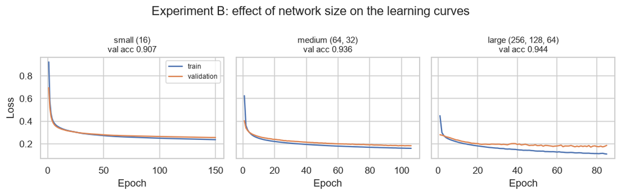

```python
plot_experiment(size_runs, 'Experiment B: effect of network size on the learning curves',
                '../images/exp_network_size.png')
```

```
small (16)             best epoch 149 | train loss 0.2374 | val loss 0.2559 | gap +0.0185
medium (64, 32)        best epoch  98 | train loss 0.1629 | val loss 0.1832 | gap +0.0203
large (256, 128, 64)   best epoch  77 | train loss 0.1158 | val loss 0.1714 | gap +0.0556
```

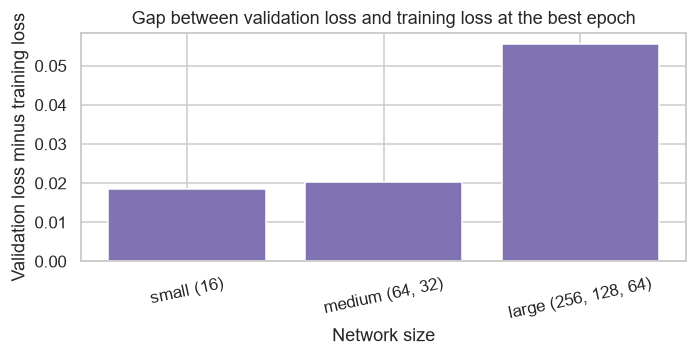

```python
gaps = []
for run in size_runs:
    h = run['histories'][0].history
    best = int(np.argmin(h['val_loss']))
    gaps.append(h['val_loss'][best] - h['loss'][best])
    print(f"{run['setting']:22s} best epoch {best+1:3d} | train loss {h['loss'][best]:.4f} "
          f"| val loss {h['val_loss'][best]:.4f} | gap {gaps[-1]:+.4f}")

fig, ax = plt.subplots(figsize=(6.5, 3.4))
ax.bar([r['setting'] for r in size_runs], gaps, color='#8172B3')
ax.set_title('Gap between validation loss and training loss at the best epoch')
ax.set_xlabel('Network size')
ax.set_ylabel('Validation loss minus training loss')
ax.axhline(0, color='grey', lw=0.8)
plt.xticks(rotation=12)
plt.tight_layout()
plt.savefig('../images/exp_size_gap.png', dpi=130)
plt.show()
```

**Takeaway:** bigger is better here, but it is not free.

The small network is clearly too weak. It runs into the epoch limit without ever catching up, so 16 neurons simply cannot hold the patterns that separate three classes.

The large network wins on validation macro F1, and it also gets there in about half as many epochs as the medium one. But look at the gap chart: the distance between validation loss and training loss is roughly **three times bigger** for the large network. That gap is the fingerprint of overfitting, the model is starting to learn things that are only true about the training rows.

So the large network is at the point where it is still gaining more than it is memorising, but it is the closest one to the edge. That is exactly the situation where dropout is supposed to help, so that is the next experiment.

### Experiment C: dropout on the large network

Dropout randomly switches off a percentage of the neurons during each training step. The network cannot rely on one single neuron to carry a feature, so it has to spread the job around. That usually makes it generalise better. I only apply it to the large network, because that is the one showing the overfitting gap.

```python
DROPOUTS = [0.0, 0.2, 0.4]

start = time.time()
dropout_runs = [run_experiment('dropout', f'dropout = {d}',
                               {'hidden_layers': [256, 128, 64], 'learning_rate': 0.001, 'dropout': d})
                for d in DROPOUTS]
print(f'done in {time.time() - start:.0f} seconds')
print()
print(results_table(dropout_runs).to_string(index=False))
```

```
  dropout = 0.0          seed 42    acc 0.9402  macro F1 0.8779  (85 epochs, 17s)
```

```
  dropout = 0.0          seed 7     acc 0.9412  macro F1 0.8801  (51 epochs, 11s)
```

```
  dropout = 0.0          seed 2024  acc 0.9503  macro F1 0.8930  (85 epochs, 17s)
```

```
  dropout = 0.2          seed 42    acc 0.9271  macro F1 0.8567  (46 epochs, 12s)
```

```
  dropout = 0.2          seed 7     acc 0.9350  macro F1 0.8708  (70 epochs, 17s)
```

```
  dropout = 0.2          seed 2024  acc 0.9321  macro F1 0.8654  (44 epochs, 11s)
```

```
  dropout = 0.4          seed 42    acc 0.9076  macro F1 0.8301  (42 epochs, 11s)
```

```
  dropout = 0.4          seed 7     acc 0.9273  macro F1 0.8581  (83 epochs, 20s)
```

```
  dropout = 0.4          seed 2024  acc 0.9240  macro F1 0.8517  (56 epochs, 14s)
```

```
done in 131 seconds

experiment       setting  val accuracy  acc spread  val macro F1  F1 spread  epochs
   dropout dropout = 0.0        0.9439      0.0045        0.8837     0.0067      73
   dropout dropout = 0.2        0.9314      0.0033        0.8643     0.0058      53
   dropout dropout = 0.4        0.9196      0.0086        0.8466     0.0120      60
```

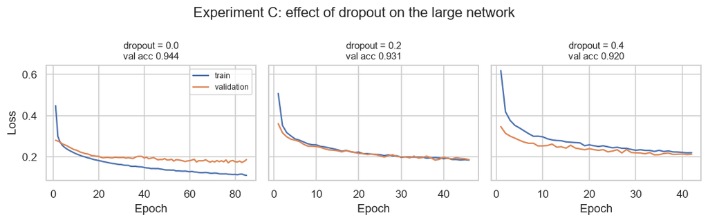

```python
plot_experiment(dropout_runs, 'Experiment C: effect of dropout on the large network',
                '../images/exp_dropout.png')
```

**Takeaway:** dropout made it worse, and I did not expect that.

Macro F1 drops from about 0.88 with no dropout, to 0.86 at 0.2, to 0.85 at 0.4. The spread between seeds is only about 0.006 to 0.012, so these differences are several times bigger than the noise. This is a real effect, not luck.

Why did the standard fix for overfitting not help? My reading is that the large network was not actually overfitting badly yet. Early stopping was already doing that job: it stops the run at the epoch where validation loss is lowest, before the memorising has time to hurt. Dropout on top of that just throws away capacity the network was still using, so it underfits instead. The curves back that up, the runs with dropout have the training and validation lines glued together, which looks tidy but at a worse loss.

**Lesson:** a regularisation technique is a cure for a specific illness. Adding it because it is famous, without first checking that the illness is there, can make the model worse. If I had run only this experiment and not the size experiment, I would have had no idea why.

### Summary of all experiments

One table with everything, so the comparison is easy to read.

```python
all_runs = lr_runs + size_runs + dropout_runs
summary = results_table(all_runs)

best_row = summary.loc[summary['val macro F1'].idxmax()]
print(summary.to_string(index=False))
print()
print(f"best setting: {best_row['experiment']} / {best_row['setting']} "
      f"with macro F1 {best_row['val macro F1']:.4f}")
```

```
   experiment              setting  val accuracy  acc spread  val macro F1  F1 spread  epochs
learning rate             lr = 0.1        0.7403      0.0220        0.6717     0.0160      10
learning rate            lr = 0.01        0.9355      0.0073        0.8708     0.0105      48
learning rate           lr = 0.001        0.9363      0.0047        0.8735     0.0073     135
learning rate          lr = 0.0001        0.9083      0.0026        0.8338     0.0039     150
 network size           small (16)        0.9074      0.0045        0.8324     0.0074     150
 network size      medium (64, 32)        0.9363      0.0047        0.8735     0.0073     135
 network size large (256, 128, 64)        0.9439      0.0045        0.8837     0.0067      73
      dropout        dropout = 0.0        0.9439      0.0045        0.8837     0.0067      73
      dropout        dropout = 0.2        0.9314      0.0033        0.8643     0.0058      53
      dropout        dropout = 0.4        0.9196      0.0086        0.8466     0.0120      60

best setting: network size / large (256, 128, 64) with macro F1 0.8837
```

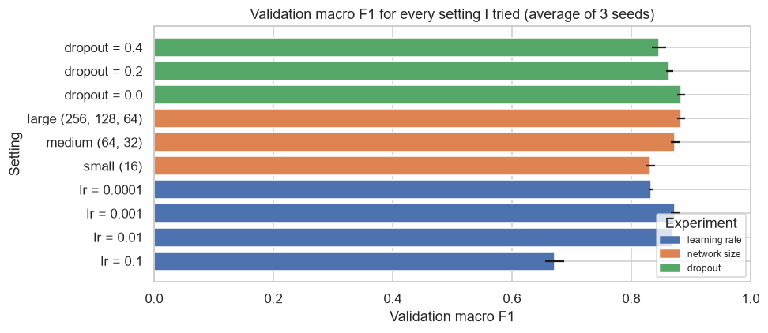

```python
fig, ax = plt.subplots(figsize=(9, 4))
colours = {'learning rate': '#4C72B0', 'network size': '#DD8452', 'dropout': '#55A868'}
ax.barh(summary['setting'], summary['val macro F1'],
        xerr=summary['F1 spread'],
        color=[colours[e] for e in summary['experiment']])
ax.set_title('Validation macro F1 for every setting I tried (average of 3 seeds)')
ax.set_xlabel('Validation macro F1')
ax.set_ylabel('Setting')
ax.set_xlim(0, 1)
handles = [plt.Rectangle((0, 0), 1, 1, color=c) for c in colours.values()]
ax.legend(handles, colours.keys(), title='Experiment', loc='lower right', fontsize=8)
plt.tight_layout()
plt.savefig('../images/experiment_summary.png', dpi=130)
plt.show()
```

**Takeaway:** once a setting is in a sensible range, everything lands between macro F1 0.83 and 0.88. The only setting that is properly broken is learning rate 0.1, which sits far below the rest at 0.67 and also has by far the biggest spread between seeds.

So the honest summary is: the difference between my worst sensible setting and my best one is about 5 points of macro F1, while the difference between the broken setting and the rest is about 20 points. Getting hyperparameters into the right ballpark matters a lot. Polishing them inside that ballpark matters much less than the data work in section 3 did.

### Bonus experiment: what if Starlink did not exist?

While exploring I noticed something that changes how I read all of these numbers.

```python
df['IS_STARLINK'] = df.OBJECT_NAME.str.upper().str.startswith('STARLINK')

print(f"Starlink objects in the data: {df.IS_STARLINK.sum():,}")
print(f"That is {df.IS_STARLINK.sum() / (df.OBJECT_TYPE == 'PAY').sum() * 100:.0f}% of all payloads")
print()
print(pd.crosstab(df.IS_STARLINK, df.OBJECT_TYPE)[order])
```

```
Starlink objects in the data: 11,136
That is 56% of all payloads

OBJECT_TYPE    PAY   R/B    DEB
IS_STARLINK
False         8731  2245  12362
True         11136     0      0
```

More than half of all the payloads in orbit are Starlink satellites. They were all launched recently, they all sit in almost the same orbit and they are all owned by US. So a big part of what my model calls "recognising a satellite" could really be "recognising a Starlink".

To find out, I rebuild the whole dataset without Starlink and train the same model on it.

```python
data_no_starlink = make_dataset(df[~df.IS_STARLINK].reset_index(drop=True))

print('class mix without Starlink (%):')
mix_ns = (pd.Series(data_no_starlink['y_train']).value_counts(normalize=True) * 100).round(1)
mix_ns.index = [CLASSES[i] for i in mix_ns.index]
print(mix_ns)

starlink_runs = [
    run_experiment('starlink', 'with Starlink', DEFAULT_PARAMS, ds=data),
    run_experiment('starlink', 'without Starlink', DEFAULT_PARAMS, ds=data_no_starlink),
]

print()
print(results_table(starlink_runs).to_string(index=False))
```

```
class mix without Starlink (%):
DEB    53.0
PAY    37.4
R/B     9.6
Name: proportion, dtype: float64
```

```
  with Starlink          seed 42    acc 0.9298  macro F1 0.8634  (106 epochs, 16s)
```

```
  with Starlink          seed 7     acc 0.9387  macro F1 0.8769  (150 epochs, 22s)
```

```
  with Starlink          seed 2024  acc 0.9404  macro F1 0.8803  (150 epochs, 24s)
```

```
  without Starlink       seed 42    acc 0.9212  macro F1 0.8699  (147 epochs, 19s)
```

```
  without Starlink       seed 7     acc 0.9206  macro F1 0.8723  (150 epochs, 18s)
```

```
  without Starlink       seed 2024  acc 0.9157  macro F1 0.8630  (150 epochs, 18s)
```

```
experiment          setting  val accuracy  acc spread  val macro F1  F1 spread  epochs
  starlink    with Starlink        0.9363      0.0047        0.8735     0.0073     135
  starlink without Starlink        0.9192      0.0024        0.8684     0.0039     149
```

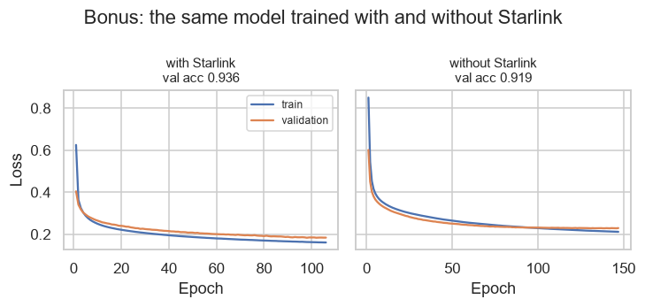

```python
plot_experiment(starlink_runs, 'Bonus: the same model trained with and without Starlink',
                '../images/exp_starlink.png')
```

**Takeaway:** the two metrics disagree, and that is the interesting part.

**Accuracy drops** from about 0.936 to 0.919. **Macro F1 barely moves**, from about 0.874 to 0.868, which is about the same size as the spread between seeds, so I cannot call that a real drop.

Why the difference? Starlink satellites are 56% of the payload class and they are extremely easy to classify: thousands of near identical objects, same owner, same launch years, almost the same orbit. Accuracy counts every row equally, so a big block of easy rows pushes it up. Macro F1 gives each of the three classes the same weight, so it does not care that one class got easier.

Removing Starlink also flips the class balance completely: debris becomes the biggest class at 53% and payloads drop to 37%. So the two runs are not only different in difficulty, they are different problems.

**What I take from this:** my headline accuracy of about 94% is partly a gift from one mega constellation. Macro F1 is the number I should quote, because it survived the test.

## 7. Final evaluation on the test set

Everything above was decided using the validation set. Now I take the settings that scored the best macro F1, train that model, and run it on the **test set**. This is the first and only time the test data is used. That is the whole point: the number it gives me is what I would expect on new objects, because nothing about those rows influenced any of my choices.

```python
best = max(all_runs, key=lambda r: r['val macro F1'])
BEST_PARAMS = best['params']

print('settings chosen by the validation results:')
print(f"  hidden layers : {BEST_PARAMS['hidden_layers']}")
print(f"  learning rate : {BEST_PARAMS['learning_rate']}")
print(f"  dropout       : {BEST_PARAMS['dropout']}")
print(f"  validation macro F1 was {best['val macro F1']:.4f}")

final_model, final_history = train_model(BEST_PARAMS, data, seed=SEED)
test_pred = final_model.predict(data['X_test'], verbose=0).argmax(axis=1)
test_acc, test_f1 = score(data['y_test'], test_pred)

print()
print(f'TEST accuracy  {test_acc:.4f}')
print(f'TEST macro F1  {test_f1:.4f}')
```

```
settings chosen by the validation results:
  hidden layers : [256, 128, 64]
  learning rate : 0.001
  dropout       : 0.0
  validation macro F1 was 0.8837
```

```
TEST accuracy  0.9368
TEST macro F1  0.8702
```

```python
comparison = pd.DataFrame([
    {'model': 'Majority class (always PAY)', 'accuracy': accuracy_score(data['y_test'], majority.predict(data['X_test'])),
     'macro F1': f1_score(data['y_test'], majority.predict(data['X_test']), average='macro')},
    {'model': 'Logistic regression', 'accuracy': accuracy_score(data['y_test'], logreg.predict(data['X_test'])),
     'macro F1': f1_score(data['y_test'], logreg.predict(data['X_test']), average='macro')},
    {'model': 'Neural network (best settings)', 'accuracy': test_acc, 'macro F1': test_f1},
]).round(4)

print('All three models on the test set:')
print(comparison.to_string(index=False))
```

```
All three models on the test set:
                         model  accuracy  macro F1
   Majority class (always PAY)    0.5764    0.2438
           Logistic regression    0.8977    0.7437
Neural network (best settings)    0.9368    0.8702
```

**Takeaway:** the neural network beats both baselines on the test set, and the difference in macro F1 is much bigger than the difference in accuracy. That is because the extra skill is mostly on the rare rocket body class, which accuracy barely notices.

### Confusion matrix

A confusion matrix shows exactly which classes get mixed up with which. Rows are the true type, columns are what the model guessed. Everything on the diagonal is correct.

I show it twice: raw counts, and normalised per row. The normalised one is easier to read here because the classes have very different sizes.

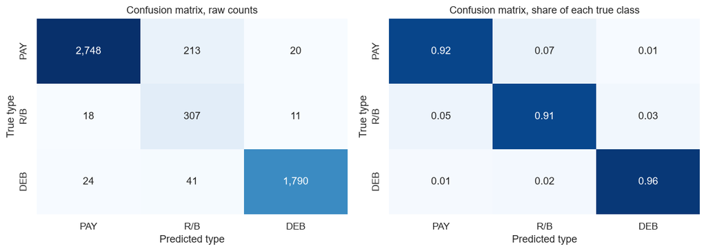

```python
cm = confusion_matrix(data['y_test'], test_pred)
cm_norm = confusion_matrix(data['y_test'], test_pred, normalize='true')

fig, axes = plt.subplots(1, 2, figsize=(11.5, 4.2))

sns.heatmap(cm, annot=True, fmt=',d', cmap='Blues', cbar=False,
            xticklabels=CLASSES, yticklabels=CLASSES, ax=axes[0])
axes[0].set_title('Confusion matrix, raw counts')
axes[0].set_xlabel('Predicted type')
axes[0].set_ylabel('True type')

sns.heatmap(cm_norm, annot=True, fmt='.2f', cmap='Blues', cbar=False, vmin=0, vmax=1,
            xticklabels=CLASSES, yticklabels=CLASSES, ax=axes[1])
axes[1].set_title('Confusion matrix, share of each true class')
axes[1].set_xlabel('Predicted type')
axes[1].set_ylabel('True type')

plt.tight_layout()
plt.savefig('../images/confusion_matrix.png', dpi=130)
plt.show()
```

```python
print('Confusion matrix as numbers (rows = true type, columns = predicted type):')
print(pd.DataFrame(cm, index=[c + ' (true)' for c in CLASSES],
                   columns=[c + ' (pred)' for c in CLASSES]))
print()
print('Per class scores on the test set:')
print(classification_report(data['y_test'], test_pred, target_names=CLASSES, digits=3))
```

```
Confusion matrix as numbers (rows = true type, columns = predicted type):
            PAY (pred)  R/B (pred)  DEB (pred)
PAY (true)        2748         213          20
R/B (true)          18         307          11
DEB (true)          24          41        1790

Per class scores on the test set:
              precision    recall  f1-score   support

         PAY      0.985     0.922     0.952      2981
         R/B      0.547     0.914     0.685       336
         DEB      0.983     0.965     0.974      1855

    accuracy                          0.937      5172
   macro avg      0.838     0.933     0.870      5172
weighted avg      0.956     0.937     0.943      5172
```

### Reading the confusion matrix

**PAY (satellites).** Almost all of them are found. The few mistakes mostly get called R/B. That makes sense, a big satellite in a high orbit looks a lot like a spent upper stage from the outside.

**DEB (debris).** Also very good. Debris is small on radar and sits in messy high inclination orbits left over from explosions, which is a clear signature.

This is a trade off, not a bug. I chose it when I turned on class weights. Without them the model would find only a third of the rocket bodies but be more trustworthy when it did say R/B. Which one is better depends on what you want: if you are surveying how much junk is in a given orbit, catching them all matters more. If a human has to check every alert, precision matters more.

The physical reason the class is hard is simple. A rocket body **is** the thing that delivered the payload, so it starts in a very similar orbit to the satellite it launched. From orbit numbers alone, the two are genuinely close.

## 8. Discussion and limitations

### What worked

- **Removing the leaky columns.** This was the single most important decision in the project. With `OBJECT_NAME` left in, the task is string matching and the result is meaningless.
- **Class weights.** Rocket body recall went from 0.32 to above 0.9. Worth the precision it cost.
- **Log scaling the wide numeric features.** Apogee ranges over five orders of magnitude and the network handles it much better after `log10`.
- **Checking the missing values instead of guessing.** I nearly imputed RCS with the median and moved on. Finding out that it is missing by launch date and not at random changed how I explain the whole feature.

### Limitations, the honest list

1. **The test set is not really "new objects".** It is a random slice of the same catalogue. Debris comes in families, one explosion makes hundreds of fragments with almost the same orbit. A random split can put siblings from the same event in both train and test, which makes the job easier than real life. Splitting by launch event or by year would be a harder and fairer test.
2. **Starlink flatters the accuracy.** 56% of the payload class is one near identical group that is very easy to recognise. The bonus experiment showed accuracy drops from 0.936 to 0.919 when I remove them, while macro F1 barely moves. So my accuracy number is partly a gift from one mega constellation, and macro F1 is the more honest headline.
3. **One snapshot in time.** The catalogue changes daily. A model trained on today's data would probably do worse on objects launched in five years, because launch patterns keep changing.
4. **Rocket body precision is low.** Useful for a survey, annoying for anything that needs a human to follow up on every alert.
5. **I only tested a small grid by hand.** Four learning rates, three sizes and three dropout values is not a real search. Something like random search or Keras Tuner would cover more ground.
6. **A neural network may not even be the right tool here.** The features are a small table of numbers and categories, which is exactly where gradient boosted trees usually win. I did not try one because the assignment is about neural networks, but I would expect it to be competitive.

### What I would do next

- Split by launch year instead of randomly, and see how much the score drops.
- Try XGBoost or a random forest as a third baseline.
- Look at which features the model actually relies on, with permutation importance.
- Try treating R/B against everything else as a two class problem, since that is where the errors are.

## 9. Reflection

*This section is mine to write. Guiding questions to answer:*

- What did I actually understand about neural networks before this project, and what do I understand now? Where did my mental picture turn out to be wrong?
- Which part of the pipeline surprised me the most? (Think about how much of the work was data and how little was the model itself.)
- What did the hyperparameter experiments teach me about how sensitive a network is? Which hyperparameter mattered more than I expected, and which mattered less?
- What does the confusion matrix tell me that a single accuracy number never could?
- Where did I use AI help, what did I check myself, and what would I not have been able to explain if somebody asked me in an exam?
- If I had to do this again from zero, what would I do differently and in which order?
- Which skill from this project do I expect to use again in another course or at work?

## 10. References

**Dataset**

1. CelesTrak. *Satellite Catalog (SATCAT)*. https://celestrak.org/satcat/ (data file downloaded 24 September 2026 from https://celestrak.org/pub/satcat.csv)
2. CelesTrak. *SATCAT Format Documentation*. https://celestrak.org/satcat/satcat-format.php

**Library documentation**

3. TensorFlow. *Keras Sequential model guide*. https://www.tensorflow.org/guide/keras/sequential_model
4. Keras. *EarlyStopping callback*. https://keras.io/api/callbacks/early_stopping/
5. Keras. *Adam optimizer*. https://keras.io/api/optimizers/adam/
6. Keras. *Dropout layer*. https://keras.io/api/layers/regularization_layers/dropout/
7. scikit learn. *Preprocessing data, StandardScaler*. https://scikit-learn.org/stable/modules/preprocessing.html
8. scikit learn. *train_test_split*. https://scikit-learn.org/stable/modules/generated/sklearn.model_selection.train_test_split.html
9. scikit learn. *Metrics and scoring, classification report and confusion matrix*. https://scikit-learn.org/stable/modules/model_evaluation.html
10. scikit learn. *compute_class_weight*. https://scikit-learn.org/stable/modules/generated/sklearn.utils.class_weight.compute_class_weight.html

**Tutorials and background I used**

11. TensorFlow. *Classification on imbalanced data*. https://www.tensorflow.org/tutorials/structured_data/imbalanced_data (this is where the class weight approach and the argument for not trusting accuracy come from)
12. scikit learn. *Common pitfalls in the interpretation of coefficients and data leakage*. https://scikit-learn.org/stable/common_pitfalls.html
13. Chollet, F. (2021). *Deep Learning with Python*, 2nd edition, Manning. Chapters 4 and 5, on classification and on overfitting.

**AI assistance**

14. Claude (Anthropic), model Opus 5, used as a coding assistant. What it helped with is logged in `AI_USAGE.md` in the repository.